# DNA methylation: Plot gene models and probe methylation

Ryan Corbett

This script plots gene models and probe methylation in patients and regions of P/LP variant-associated differential methylation

# Load libraries

```r
suppressPackageStartupMessages({
  library(ggplot2)
  library(tidyverse)
  library(ggpubr)
  library(ggrepel)
  library(rtracklayer)
  library(ggbio)
})

# Set up directories
root_dir <- rprojroot::find_root(rprojroot::has_dir(".git"))

data_dir <- file.path(root_dir, "data")
analysis_dir <- file.path(root_dir, "analyses", "methylation")
input_dir <- file.path(analysis_dir, "input")
results_dir <- file.path(analysis_dir, "results")
plot_dir <- file.path(analysis_dir, "plots")

# If the directory does not exist, create it
if (!dir.exists(results_dir)) {
  dir.create(results_dir, recursive = TRUE)
}

# source publication theme
source(file.path(root_dir, "figures", "theme.R"))

# set seed to reproduce plots
set.seed(2024)
```

Set file paths

```r
gtf_file <- file.path(data_dir,
                      "gencode.v39.primary_assembly.annotation.gtf.gz")

hist_cohort_file <- file.path(results_dir,
                              "germline-primary-plus-tumor-histologies-methylation.tsv")

methyl_zscore_file <- file.path(results_dir, "pbta-germline-methylation-beta-zscores.tsv")
```

Load GTF and filter for exons

```r
gtf <- rtracklayer::import(gtf_file, format = "gtf")

exons <- gtf[gtf$type %in% c("exon", "intron")]
```

Plot MSH2 gene model and highlight: - SV in sample BS_S75EZJDW (chr2:47402604-47422500) - Region of differentially methylated probes in same patient’s tumor (chr2:47402604-47403155)

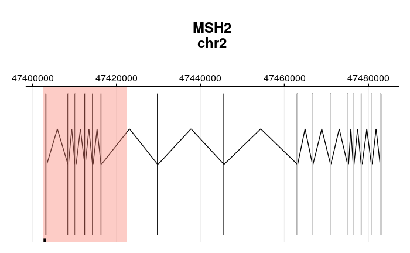

```r
gene_of_interest <- "MSH2"
transcript_of_interest <- "MSH2-201"
msh2_exons <- exons[exons$transcript_name == transcript_of_interest & !is.na(exons$transcript_name)]

ggplot() +
  geom_alignment(msh2_exons, type = type, fill = "grey80") +
  theme_Publication() +
  labs(title = "MSH2\nchr2") +
  scale_x_continuous(position = "top") +
  geom_rect(aes(xmin = 47402401, xmax = 47422500, ymin = -Inf, ymax = Inf),
            fill = "salmon", alpha = 0.4) +
  geom_segment(aes(x = 47402604, xend = 47403155, y = -Inf),
            col = "black", size = 4)
ggsave(file.path(plot_dir, "msh2-gene-model.pdf"),
       width = 6, height = 2, units = "in")
```

Plot 2 RECQL4 gene models and highlight: - P/LP variants in two patients - Regions of differentially methylated probes matched tumors

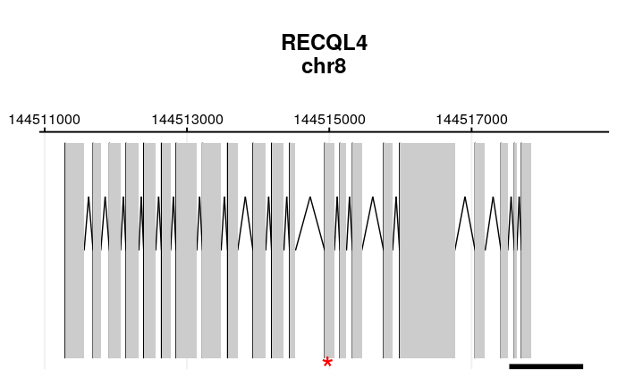

```r
transcript_of_interest <- "RECQL4-209"
recql4_exons <- exons[exons$transcript_name == transcript_of_interest & !is.na(exons$transcript_name)]

ggplot() +
  geom_alignment(recql4_exons, type = type, fill = "grey80") +
  theme_Publication() +
  labs(title = "RECQL4\nchr8") +
  scale_x_continuous(position = "top") +
  geom_text(aes(x = 144514982, y = -Inf, label = "*"),
            col = "red", size = 10) +
  geom_segment(aes(x = 144517529, xend = 144518568, y = -Inf),
            col = "black", size = 4)
ggsave(file.path(plot_dir, "recql4-gene-model-BS_PF7546KW.pdf"),
       width = 6, height = 2, units = "in")
```

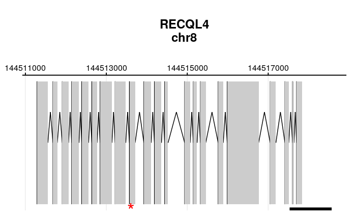

```r
ggplot() +
  geom_alignment(recql4_exons, type = type, fill = "grey80") +
  theme_Publication() +
  labs(title = "RECQL4\nchr8") +
  scale_x_continuous(position = "top") +
  geom_text(aes(x = 144513610, y = -Inf, label = "*"),
            col = "red", size = 10) +
  geom_segment(aes(x = 144517529, xend = 144518568, y = -Inf),
            col = "black", size = 4)
ggsave(file.path(plot_dir, "recql4-gene-model-BS_TV8HD883.pdf"),
       width = 6, height = 2, units = "in")
```

Plot 2 MSH6 gene model and highlight: - P/LP variant in sample BS_G113MX63 (chr2:47800909) - Regions of differentially methylated probes matched tumor (chr2:47782559-47784062)

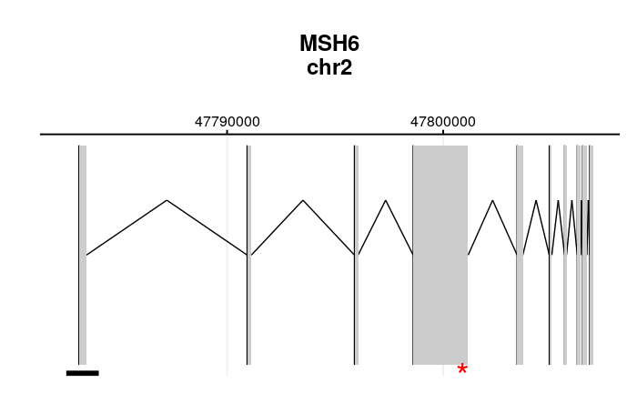

```r
transcript_of_interest <- "MSH6-201"
msh6_exons <- exons[exons$transcript_name == transcript_of_interest & !is.na(exons$transcript_name)]

ggplot() +
  geom_alignment(msh6_exons, type = type, fill = "grey80") +
  theme_Publication() +
  labs(title = "MSH6\nchr2") +
  scale_x_continuous(position = "top") +
  geom_text(aes(x = 47800909, y = -Inf, label = "*"),
            col = "red", size = 10) +
  geom_segment(aes(x = 47782559, xend = 47784062, y = -Inf),
            col = "black", size = 4)
ggsave(file.path(plot_dir, "msh6-gene-model-BS_G113MX63.pdf"),
       width = 6, height = 2, units = "in")
```

Load differential methylation data and create a plotting data frame

```r
methyl_zscores <- read_tsv(methyl_zscore_file)
methyl_plot_df <- methyl_zscores %>%
  # create rows for sample-level probe beta values
  dplyr::select(Kids_First_Biospecimen_ID_methyl,
                Kids_First_Biospecimen_ID_normal,
                Probe_ID, probe_position,
                Hugo_Symbol,
                probe_gene_feature,
                beta_value_sample,
                sample_beta_zscore_group) %>%
  # define group as Biospecimen ID
  dplyr::mutate(group = Kids_First_Biospecimen_ID_methyl) %>%
  dplyr::rename(beta_value = beta_value_sample) %>%
  # append additional rows where beta value represents mean (excluding sample)
  # define this group as "Other samples"
  bind_rows(methyl_zscores %>%
                dplyr::select(Kids_First_Biospecimen_ID_methyl,
                              Kids_First_Biospecimen_ID_normal,
                              Probe_ID, probe_position,
                              Hugo_Symbol,
                              probe_gene_feature,
                              mean_beta_group) %>%
              dplyr::rename(beta_value = mean_beta_group) %>%
              dplyr::mutate(group = "Other samples")) %>%
  # add signif value for text plotting
  dplyr::mutate(sig_zscore = case_when(
    abs(sample_beta_zscore_group) > 2 ~ "**",
    TRUE ~ NA_character_
  ))
```

Plot RECQL4 promoter methylation in BS_TV8HD883 vs. other samples

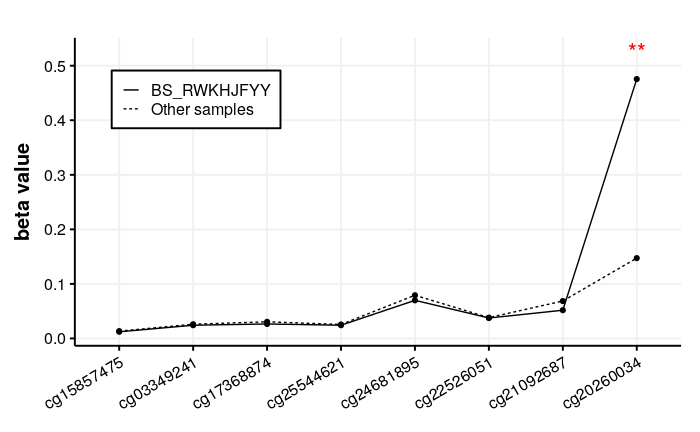

```r
methyl_plot_df %>%
  dplyr::filter(Hugo_Symbol == "RECQL4",
                Kids_First_Biospecimen_ID_normal == "BS_TV8HD883",
                probe_gene_feature == "promoter") %>%
  dplyr::arrange(probe_position) %>%
  dplyr::mutate(Probe_ID = fct_relevel(Probe_ID,
                                       unique(Probe_ID))) %>%

  ggplot(aes(x = Probe_ID, y = beta_value, group = group)) +
  geom_line(aes(linetype=group)) +
  geom_point() +
  geom_text(aes(x = Probe_ID, y = beta_value+0.05, label = sig_zscore),
            color = "red", size = 6) +
  labs(x = NULL, y = "beta value", linetype = NULL) +
  theme_Publication() +
  theme(axis.text.x = element_text(angle = 30, hjust = 1),
        legend.position = c(.2,0.8),
        legend.background = element_rect(color = "black"))
ggsave(file.path(plot_dir, "RECQL4-BS_RWKHJFYY-promoter-methylation.pdf"),
       width = 6, height = 3, units = "in")
```

Plot RECQL4 promoter methylation in BS_PF7546KW vs. other samples

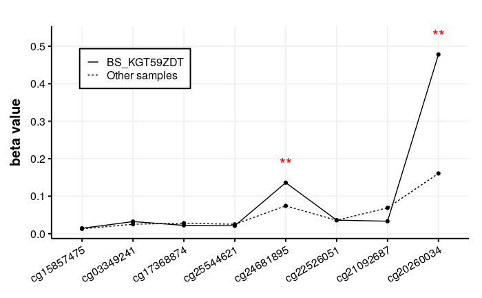

```r
methyl_plot_df %>%
  dplyr::filter(Hugo_Symbol == "RECQL4",
                Kids_First_Biospecimen_ID_normal == "BS_PF7546KW",
                probe_gene_feature == "promoter") %>%
  dplyr::arrange(probe_position) %>%
  dplyr::mutate(Probe_ID = fct_relevel(Probe_ID,
                                       unique(Probe_ID))) %>%

  ggplot(aes(x = Probe_ID, y = beta_value, group = group)) +
  geom_line(aes(linetype=group)) +
  geom_point() +
  geom_text(aes(x = Probe_ID, y = beta_value+0.05, label = sig_zscore),
            color = "red", size = 6) +
  labs(x = NULL, y = "beta value", linetype = NULL) +
  labs(x = NULL, y = "beta value", linetype = NULL) +
  theme_Publication() +
  theme(axis.text.x = element_text(angle = 30, hjust = 1),
        legend.position = c(.2,0.8),
        legend.background = element_rect(color = "black"))
ggsave(file.path(plot_dir, "RECQL4-BS_KGT59ZDT-promoter-methylation.pdf"),
       width = 6, height = 3, units = "in")
```

Plot MSH2 promoter methylation in BS_S75EZJDW vs. other samples

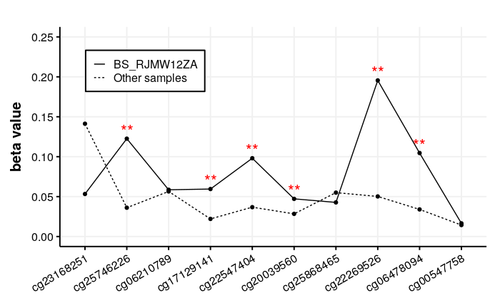

```r
methyl_plot_df %>%
  dplyr::filter(Hugo_Symbol == "MSH2",
                Kids_First_Biospecimen_ID_normal == "BS_S75EZJDW",
                probe_gene_feature == "promoter") %>%
  dplyr::arrange(probe_position) %>%
  dplyr::mutate(Probe_ID = fct_relevel(Probe_ID,
                                       unique(Probe_ID))) %>%

  ggplot(aes(x = Probe_ID, y = beta_value, group = group)) +
  geom_line(aes(linetype=group)) +
  geom_point() +
  geom_text(aes(x = Probe_ID, y = beta_value+0.01, label = sig_zscore),
            color = "red", size = 6) +
  ylim(c(0,.25)) +
  labs(x = NULL, y = "beta value", linetype = NULL) +
  labs(x = NULL, y = "beta value", linetype = NULL) +
  theme_Publication() +
  theme(axis.text.x = element_text(angle = 30, hjust = 1),
        legend.position = c(.2,0.8),
        legend.background = element_rect(color = "black"))
ggsave(file.path(plot_dir, "MSH2-BS_RJMW12ZA-promoter-methylation.pdf"),
       width = 6, height = 3, units = "in")
```

Plot MSH6 promoter methylation in BS_G113MX63 vs. other samples

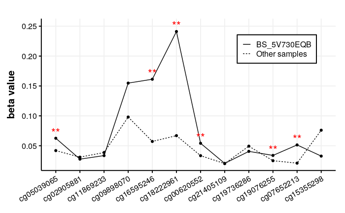

```r
methyl_plot_df %>%
  dplyr::filter(Hugo_Symbol == "MSH6",
                Kids_First_Biospecimen_ID_normal == "BS_G113MX63",
                probe_gene_feature == "promoter",
                probe_position > 47695466) %>%
  dplyr::arrange(probe_position) %>%
  dplyr::mutate(Probe_ID = fct_relevel(Probe_ID,
                                       unique(Probe_ID))) %>%

  ggplot(aes(x = Probe_ID, y = beta_value, group = group)) +
  geom_line(aes(linetype=group)) +
  geom_point() +
  geom_text(aes(x = Probe_ID, y = beta_value+0.01, label = sig_zscore),
            color = "red", size = 6) +
  labs(x = NULL, y = "beta value", linetype = NULL) +
  labs(x = NULL, y = "beta value", linetype = NULL) +
  theme_Publication() +
  theme(axis.text.x = element_text(angle = 30, hjust = 1),
        legend.position = c(.8,0.8),
        legend.background = element_rect(color = "black"))
ggsave(file.path(plot_dir, "MSH6-BS_5V730EQB-promoter-methylation.pdf"),
       width = 6, height = 3, units = "in")
```